# assessment 3 wine report

yingchaozhao S4664370

2022-04-07

## R Markdown

```r
library(tidyverse)
library(tidymodels)
```

```r
library(knitr)
library(ggplot2)
library(skimr)
library(dplyr)
```

## ———————————————————————————————————–

# EXECUTIVE SUMMARY

[This dataset illustrates the details of wine, for instances, the country, description, designation, points, price, province, taster_name, title, variety and winery. From this business report, it will argues which factor affects the rating of the wine. We will focus on the analysis from two aspects. One is the relationship between the country and the point, another is the relationship between the price and the points. ]

## ———————————————————————————————————–

# INTRODUCTION

[This dataset is a wine-enthusiast ratings dataset from Feorgios Karamanis sharing from Kaggle. In recent years, healthy diet is the most important thing for individuals. Wine is becoming more and more popular at wine tables.Many people are also very concerned about the price, origin and rating of the wine.]

## —————————————————————————————————–

# BUSINESS PROBLEM

[This report will explore if the country of a wine and the points of a wine will affect a wine’s rating or points can be predicted.]

**Major Question:** Can we determine which major factors significantly influencing the wine enthusiast’s ratings?

*Sub-questions:*

Q1. Can we predict how the price affects the overall wine rating?

Q2. Which of the wine characteristics affect the overall wine rating?

## —————————————————————————————————–

# ABOUT THE DATASET [wine_rating]

The dataset shows how many factors can affect the rating of a wine.

## Load the dataset

```r
wine_ratings <- readr::read_csv("https://raw.githubusercontent.com/rfordatascience/tidytuesday/master/data/2019/2019-05-28/winemag-data-130k-v2.csv")
```

```
## * `` -> ...1
```

## Data Analysis

### 1. It is important to change the “character” variables into a “factor” for better analysis.

```r
wine_ratings <- wine_ratings %>%
  mutate_if(is.character, factor)
```

### 2. let’s see some details from this data.

```r
skim(wine_ratings)
```

Data summary

| Name | wine_ratings |
| --- | --- |
| Number of rows | 129971 |
| Number of columns | 14 |
| _______________________ |  |
| Column type frequency: |  |
| factor | 11 |
| numeric | 3 |
| ________________________ |  |
| Group variables | None |

**Variable type: factor**

| skim_variable | n_missing | complete_rate | ordered | n_unique | top_counts |
| --- | --- | --- | --- | --- | --- |
| country | 63 | 1.00 | FALSE | 43 | US: 54504, Fra: 22093, Ita: 19540, Spa: 6645 |
| description | 0 | 1.00 | FALSE | 119955 | Cig: 3, Gra: 3, Rip: 3, Sed: 3 |
| designation | 37465 | 0.71 | FALSE | 37979 | Res: 2009, Est: 1322, Res: 1259, Ris: 698 |
| province | 63 | 1.00 | FALSE | 425 | Cal: 36247, Was: 8639, Bor: 5941, Tus: 5897 |
| region_1 | 21247 | 0.84 | FALSE | 1229 | Nap: 4480, Col: 4124, Rus: 3091, Cal: 2629 |
| region_2 | 79460 | 0.39 | FALSE | 17 | Cen: 11065, Son: 9028, Col: 8103, Nap: 6814 |
| taster_name | 26244 | 0.80 | FALSE | 19 | Rog: 25514, Mic: 15134, Ker: 10776, Vir: 9537 |
| taster_twitter_handle | 31213 | 0.76 | FALSE | 15 | @vo: 25514, @wi: 15134, @ke: 10776, @vb: 9537 |
| title | 0 | 1.00 | FALSE | 118840 | Glo: 11, Kor: 9, Seg: 8, Glo: 7 |
| variety | 1 | 1.00 | FALSE | 707 | Pin: 13272, Cha: 11753, Cab: 9472, Red: 8946 |
| winery | 0 | 1.00 | FALSE | 16757 | Win: 222, Tes: 218, DFJ: 215, Wil: 211 |

**Variable type: numeric**

| skim_variable | n_missing | complete_rate | mean | sd | p0 | p25 | p50 | p75 | p100 | hist |
| --- | --- | --- | --- | --- | --- | --- | --- | --- | --- | --- |
| …1 | 0 | 1.00 | 64985.00 | 37519.54 | 0 | 32492.5 | 64985 | 97477.5 | 129970 | ▇▇▇▇▇ |
| points | 0 | 1.00 | 88.45 | 3.04 | 80 | 86.0 | 88 | 91.0 | 100 | ▂▇▇▂▁ |
| price | 8996 | 0.93 | 35.36 | 41.02 | 4 | 17.0 | 25 | 42.0 | 3300 | ▇▁▁▁▁ |

```r
summary(wine_ratings)
```

```
##       ...1            country
##  Min.   :     0   US      :54504
##  1st Qu.: 32492   France  :22093
##  Median : 64985   Italy   :19540
##  Mean   : 64985   Spain   : 6645
##  3rd Qu.: 97478   Portugal: 5691
##  Max.   :129970   (Other) :21435
##                   NA's    :   63
##                                                                                                                                                                                                                                                                                                         d…
##  Cigar box, café au lait, and dried tobacco aromas are followed by coffee and cherry flavors, with barrel spices lingering on the finish. The wood gets a bit out front but it still delivers enjoyment.                                                                                                 …
##  Gravenstein apple, honeysuckle and jasmine aromas show on the relatively boisterous nose of this bottling from a large vineyard on Highway 46 east of Paso Robles. There is compellingly grippy texture to the sip, with ripe flavors of pear and honeydew melon. A salty acidity takes it to the next l…
##  Ripe plum, game, truffle, leather and menthol are some of the aromas you'll find on this earthy wine. The tightly wound palate offers dried black cherry, chopped sage, mint and roasted coffee bean alongside raspy tannins that leave a mouth-drying finish.                                          …
##  Seductively tart in lemon pith, cranberry and pomegranate, this refreshing, light-bodied quaff is infinitely enjoyable, both on its own or at the table. It continues to expand on the palate into an increasing array of fresh flavors, finishing in cherry and orange.                                …
##  Stalky aromas suggest hay and green herbs, with raspberry in the backdrop. It's hot and short in terms of mouthfeel, with herbal flavors leading the way and berry fruit running behind. Dry red fruit and herbal notes dominate the finish.                                                            …
##  This zesty red has pretty aromas that suggest small red berry, blue flower and a whiff of moist soil. The vibrant palate offers sour cherry, pomegranate and a hint of anise alongside zesty acidity and refined tannins.                                                                               …
##  (Other)                                                                                                                                                                                                                                                                                                 …
##        designation        points           price               province
##  Reserve     : 2009   Min.   : 80.00   Min.   :   4.00   California:36247
##  Estate      : 1322   1st Qu.: 86.00   1st Qu.:  17.00   Washington: 8639
##  Reserva     : 1259   Median : 88.00   Median :  25.00   Bordeaux  : 5941
##  Riserva     :  698   Mean   : 88.45   Mean   :  35.36   Tuscany   : 5897
##  Estate Grown:  621   3rd Qu.: 91.00   3rd Qu.:  42.00   Oregon    : 5373
##  (Other)     :86597   Max.   :100.00   Max.   :3300.00   (Other)   :67811
##  NA's        :37465                    NA's   :8996      NA's      :   63
##                  region_1                  region_2
##  Napa Valley         : 4480   Central Coast    :11065
##  Columbia Valley (WA): 4124   Sonoma           : 9028
##  Russian River Valley: 3091   Columbia Valley  : 8103
##  California          : 2629   Napa             : 6814
##  Paso Robles         : 2350   Willamette Valley: 3423
##  (Other)             :92050   (Other)          :12078
##  NA's                :21247   NA's             :79460
##             taster_name     taster_twitter_handle
##  Roger Voss       :25514   @vossroger  :25514
##  Michael Schachner:15134   @wineschach :15134
##  Kerin O’Keefe    :10776   @kerinokeefe:10776
##  Virginie Boone   : 9537   @vboone     : 9537
##  Paul Gregutt     : 9532   @paulgwine  : 9532
##  (Other)          :33234   (Other)     :28265
##  NA's             :26244   NA's        :31213
##                                                      title
##  Gloria Ferrer NV Sonoma Brut Sparkling (Sonoma County) :    11
##  Korbel NV Brut Sparkling (California)                  :     9
##  Segura Viudas NV Extra Dry Sparkling (Cava)            :     8
##  Gloria Ferrer NV Blanc de Noirs Sparkling (Carneros)   :     7
##  Ruinart NV Brut Rosé  (Champagne)                      :     7
##  Segura Viudas NV Aria Estate Extra Dry Sparkling (Cava):     7
##  (Other)                                                :129922
##                      variety                     winery
##  Pinot Noir              :13272   Wines & Winemakers:   222
##  Chardonnay              :11753   Testarossa        :   218
##  Cabernet Sauvignon      : 9472   DFJ Vinhos        :   215
##  Red Blend               : 8946   Williams Selyem   :   211
##  Bordeaux-style Red Blend: 6915   Louis Latour      :   199
##  (Other)                 :79612   Georges Duboeuf   :   196
##  NA's                    :    1   (Other)           :128710
```

Before we start to find the relations, we will create a new variable and divide the ‘points’ column to 3 levels. The points > 95, the name is ‘excellent’, points < 85, named ‘average’, 85 < points < 95, named ‘good’.

```r
new_wine_ratings <- wine_ratings %>%
  mutate(new_wine_ratings = case_when(points > 95 ~ 'excellent',  points < 85 ~ 'average', TRUE ~'good'))

new_wine_ratings %>%
  count(new_wine_ratings) %>%
  kable()
```

| new_wine_ratings | n |
| --- | --- |
| average | 12430 |
| excellent | 881 |
| good | 116660 |

We can see that there are 12430 valus of ‘average’, 116660 valus of ‘good’, 881 valus of ‘excellent’.

### Can we predict how the price affects the overall wine rating?

To find this relation, let’s plot the `price` as X-axis and `points` as Y-axis. We then use the linear regression to see how they are related.

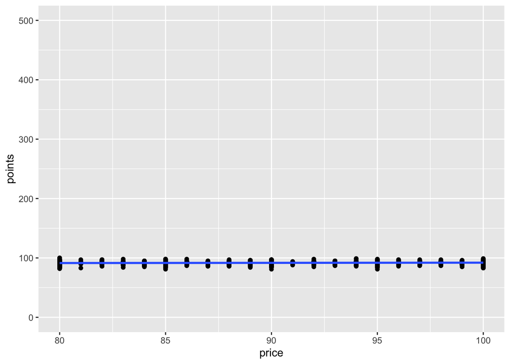

```r
new_wine_ratings %>%
  ggplot(aes(price, points), na.rm = TRUE) +
  geom_point(, na.rm = TRUE) +
  geom_smooth(method = lm, se = FALSE, na.rm = TRUE) +
  scale_x_continuous(limits=c(80,100))+
  scale_y_continuous(limits=c(0,500))
```

### Is the relation between the `price` and `points` dependent on `wine_rating`?

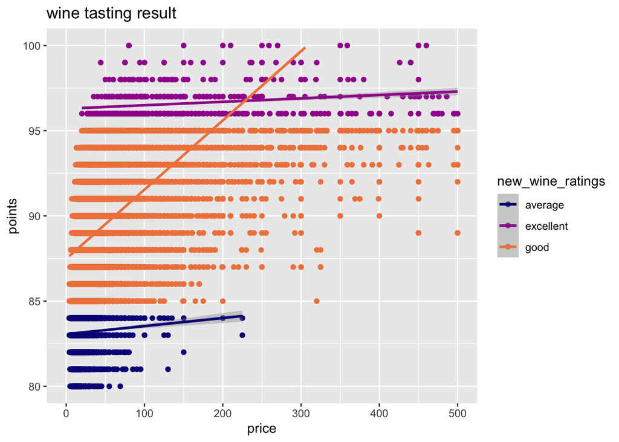

```r
new_wine_ratings %>%
  ggplot(aes(price, points, colour = new_wine_ratings), na.rm = TRUE) +
  geom_point( , na.rm = TRUE) +
  geom_smooth(formula = y ~ x, method = "lm", na.rm = TRUE) +
  scale_y_continuous(limits=c(80,100)) +
  scale_x_continuous(limits=c(0,500)) +
  scale_color_viridis_d(option = "plasma", end = .7) +
  labs(x = "price", y = "points", colour = "new_wine_ratings", title = "wine tasting result")
```

We can see that all the slopes show a positive relation. However, these slopes look different. According to the graph, two lines intersect at a single point. Price around 225 and points around 97. This point could be used as utility maximization which illustrates that wines in this combination are the most popular price and point.

This also goes on to show that we can predict the correct `wine_rating` to bring a wine of `price` to a certain of`points`.

## —————————————————————————————————–

# PREDICTIVE ANALYSIS

From our descriptive analysis, we have found that the rating of a wine can be predicted by knowing their `price` and `points`. We will now build a model to make these predictions.

### Step 1: Split the dataset into Training & Testing datasets.

```r
new_wine_ratings_split <- initial_split(new_wine_ratings)
new_wine_ratings_train <- training(new_wine_ratings_split)
new_wine_ratings_test <- testing(new_wine_ratings_split)
```

### Step 2: Pre-process the data.

#### 2.1 Set the recipe & get the ingredients - `recipe()`

```r
new_wine_ratings_recipe1 <- recipe(points ~ ., data = new_wine_ratings_train)

summary(new_wine_ratings_recipe1)
```

```
## # A tibble: 15 × 4
##    variable              type    role      source
##    <chr>                 <chr>   <chr>     <chr>
##  1 ...1                  numeric predictor original
##  2 country               nominal predictor original
##  3 description           nominal predictor original
##  4 designation           nominal predictor original
##  5 price                 numeric predictor original
##  6 province              nominal predictor original
##  7 region_1              nominal predictor original
##  8 region_2              nominal predictor original
##  9 taster_name           nominal predictor original
## 10 taster_twitter_handle nominal predictor original
## 11 title                 nominal predictor original
## 12 variety               nominal predictor original
## 13 winery                nominal predictor original
## 14 new_wine_ratings      nominal predictor original
## 15 points                numeric outcome   original
```

#### 2.2 Write the recipe steps - `step_xxx()`

Success of modelling depends on the “quality” of data. To ensure this quality, there are few transformations that are necessary in our dataset.

- Whenever we have numeric values in our dataset, to avoid the **outliers** we need to normalise it by **“Centering”** & **“Scalling”** - [`step_center()` & `step_scale()`]
- We also need to remove any numeric variables that are closely related (=correlated) - [`step_corr()`]

```r
new_wine_ratings_recipe1 <- new_wine_ratings_recipe1 %>%
  # Normalises numeric data to have a mean of zero
  step_center(all_numeric(), -all_outcomes()) %>%
  # Normalizes numeric data to have a standard deviation of one
  step_scale(all_numeric(), -all_outcomes()) %>%
  # removes variables that are too closely related
  step_corr(all_numeric())
```

#### 2.3 Get ready with the prep - `prep()`

```r
new_wine_ratings_prep1 <- prep(new_wine_ratings_recipe1, training = new_wine_ratings_train)
```

#### 2.4 Bake the recipe - `bake()`

```r
new_wine_ratings_bake1 <- bake(new_wine_ratings_prep1, new_wine_ratings_train)

summary(new_wine_ratings_bake1)
```

```
##       ...1               country
##  Min.   :-1.729602   US      :40904
##  1st Qu.:-0.866907   France  :16626
##  Median :-0.001734   Italy   :14614
##  Mean   : 0.000000   Spain   : 5001
##  3rd Qu.: 0.865216   Portugal: 4312
##  Max.   : 1.731860   (Other) :15970
##                      NA's    :   51
##                                                                                                                                                                                                                                                                                   description
##  Cigar box, café au lait, and dried tobacco aromas are followed by coffee and cherry flavors, with barrel spices lingering on the finish. The wood gets a bit out front but it still delivers enjoyment.                                                                                :    3
##  Ripe plum, game, truffle, leather and menthol are some of the aromas you'll find on this earthy wine. The tightly wound palate offers dried black cherry, chopped sage, mint and roasted coffee bean alongside raspy tannins that leave a mouth-drying finish.                         :    3
##  Seductively tart in lemon pith, cranberry and pomegranate, this refreshing, light-bodied quaff is infinitely enjoyable, both on its own or at the table. It continues to expand on the palate into an increasing array of fresh flavors, finishing in cherry and orange.               :    3
##  ‘Na Vota is a fresh and easygoing wine that is vinified in stainless steel to maintain its fresh berry and floral aromas. The wine has medium structure and staying power but does reward the palate with its crisp acidic finish.                                                     :    2
##  “Open and drink” the instructions should read, as this smooth and luscious wine is best enjoyed young. Half was barrel-fermented, yielding flavors of caramel, almond paste and buttered nuts. Pair with leek, bacon and potato soup, says the winery, which sounds just about perfect.:    2
##  100% Malbec, it's redolent with dark plums, wild blueberries and peppery spices. The soft, silky flavors are light but have good concentration with the oak (80% American) seeming quite dialed back.                                                                                  :    2
##  (Other)                                                                                                                                                                                                                                                                                :97463
##        designation        price              province
##  Reserve     : 1453   Min.   :-0.735   California:27227
##  Estate      : 1006   1st Qu.:-0.431   Washington: 6493
##  Reserva     :  941   Median :-0.244   Bordeaux  : 4479
##  Riserva     :  509   Mean   : 0.000   Tuscany   : 4383
##  Estate Grown:  468   3rd Qu.: 0.153   Oregon    : 4002
##  (Other)     :65014   Max.   :76.282   (Other)   :50843
##  NA's        :28087   NA's   :6805     NA's      :   51
##                  region_1                  region_2
##  Napa Valley         : 3401   Central Coast    : 8366
##  Columbia Valley (WA): 3065   Sonoma           : 6740
##  Russian River Valley: 2310   Columbia Valley  : 6103
##  California          : 1972   Napa             : 5121
##  Paso Robles         : 1790   Willamette Valley: 2543
##  (Other)             :69036   (Other)          : 9057
##  NA's                :15904   NA's             :59548
##             taster_name     taster_twitter_handle
##  Roger Voss       :19223   @vossroger  :19223
##  Michael Schachner:11361   @wineschach :11361
##  Kerin O’Keefe    : 8106   @kerinokeefe: 8106
##  Paul Gregutt     : 7123   @paulgwine  : 7123
##  Virginie Boone   : 7109   @vboone     : 7109
##  (Other)          :24866   (Other)     :21181
##  NA's             :19690   NA's        :23375
```

[output cut: 9 more lines]

```
##  Pinot Noir              : 9937   Testarossa           :  175
##  Chardonnay              : 8848   Wines & Winemakers   :  170
##  Cabernet Sauvignon      : 7051   DFJ Vinhos           :  162
##  Red Blend               : 6633   Williams Selyem      :  152
##  Bordeaux-style Red Blend: 5200   Chateau Ste. Michelle:  146
##  (Other)                 :59808   Georges Duboeuf      :  146
##  NA's                    :    1   (Other)              :96527
##   new_wine_ratings     points
##  average  : 9308   Min.   : 80.00
##  excellent:  674   1st Qu.: 86.00
##  good     :87496   Median : 88.00
##                    Mean   : 88.45
##                    3rd Qu.: 91.00
##                    Max.   :100.00
##
```

### Step 3: Build a model

[**For this modelling, our Output variable is Numeric. So, we will use Linear Modelling `lm()`.**]

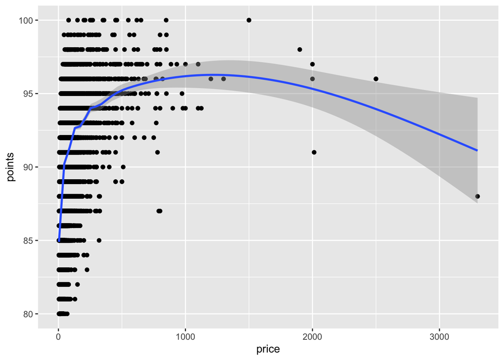

```r
ggplot(new_wine_ratings, aes( price, points)) +
  geom_point(, na.rm = TRUE) +
  stat_smooth(, na.rm = TRUE)
```

```r
cor(new_wine_ratings$price, new_wine_ratings$points, use = "complete.obs")
```

```
## [1] 0.4161667
```

```r
model1 <- lm(price ~ points, data = new_wine_ratings)

summary(model1)
```

```
##
## Call:
## lm(formula = price ~ points, data = new_wine_ratings)
##
## Residuals:
##    Min     1Q Median     3Q    Max
##  -57.9  -15.0   -5.4    7.2 3267.0
##
## Coefficients:
##               Estimate Std. Error t value Pr(>|t|)
## (Intercept) -460.46243    3.11657  -147.7   <2e-16 ***
## points         5.60750    0.03523   159.2   <2e-16 ***
## ---
## Signif. codes:  0 '***' 0.001 '**' 0.01 '*' 0.05 '.' 0.1 ' ' 1
##
## Residual standard error: 37.3 on 120973 degrees of freedom
##   (8996 observations deleted due to missingness)
## Multiple R-squared:  0.1732, Adjusted R-squared:  0.1732
## F-statistic: 2.534e+04 on 1 and 120973 DF,  p-value: < 2.2e-16
```

From our descriptive analysis, we also found that we can predict wine characteristics affect the overall wine rating. We will now build a model to make these predictions.

### Step 1: Split the dataset into Training & Testing datasets.

We will use the same training and testing dataset created earlier for Model 1. So, no need to recreate.

### Step 2: Pre-process the data.

#### 2.1 Set the recipe & get the ingredients - `recipe()`

Since we are predicting the country of the wine, `country` is our **Output variable** and the others are our **Input variables** or **Predictors**.

```r
new_wine_ratings_recipe2 <- recipe(country ~ ., data = new_wine_ratings_train)

summary(new_wine_ratings_recipe2)
```

```
## # A tibble: 15 × 4
##    variable              type    role      source
##    <chr>                 <chr>   <chr>     <chr>
##  1 ...1                  numeric predictor original
##  2 description           nominal predictor original
##  3 designation           nominal predictor original
##  4 points                numeric predictor original
##  5 price                 numeric predictor original
##  6 province              nominal predictor original
##  7 region_1              nominal predictor original
##  8 region_2              nominal predictor original
##  9 taster_name           nominal predictor original
## 10 taster_twitter_handle nominal predictor original
## 11 title                 nominal predictor original
## 12 variety               nominal predictor original
## 13 winery                nominal predictor original
## 14 new_wine_ratings      nominal predictor original
## 15 country               nominal outcome   original
```

#### 2.2 Write the recipe steps - `step_xxx()`

Success of modelling depends on the “quality” of data. To ensure this quality, there are few transformations that are necessary in our dataset.

- Whenever we have numeric values in our dataset, to avoid the **outliers** we need to normalise it by **“Centering”** & **“Scalling”** - [`step_center()` & `step_scale()`]
- We also need to remove any numeric variables that are closely related (=correlated) - [`step_corr()`]

```r
new_wine_ratings_recipe2 <- new_wine_ratings_recipe2 %>%
  # Normalises numeric data to have a mean of zero
  step_center(all_numeric(), -all_outcomes()) %>%
  # Normalizes numeric data to have a standard deviation of one
  step_scale(all_numeric(), -all_outcomes()) %>%
  # removes variables that are too closely related
  step_corr(all_numeric())
```

#### 2.3 Get ready with the prep - `prep()`

```r
new_wine_ratings_prep2 <- prep(new_wine_ratings_recipe2, training = new_wine_ratings_train)
```

#### 2.4 Bake the recipe - `bake()`

```r
new_wine_ratings_bake2 <- bake(new_wine_ratings_prep2, new_wine_ratings_train)
```